# 社會科學統計方法

資料子集合、條件判斷、迴圈(v2.0)

蔡佳泓

2018/3/20

# 1 課程目標

本週上課將介紹`R`的控制流程，也就是條件判斷與迴圈，讓電腦可以按照給定的邏輯，反覆執行指令，一直到滿足條件為止，這對於運算以及擷取資料非常有幫助。例如我們隨機找到10位民眾，想依據民眾的年齡，判斷是否應該訪問他們，並且顯示成為一個資料框，可寫語法運算如下：

```r
age<-c(34, 12, 19, 21, 22, 30, 16, 18, 17, 39)
 f<-function(x){
  interview<-ifelse(x>=18, "Yes", "No")
  return(data.frame(Age=x, Interview=interview, row.names=NULL))
 }

f(age)
```

```
##    Age Interview
## 1   34       Yes
## 2   12        No
## 3   19       Yes
## 4   21       Yes
## 5   22       Yes
## 6   30       Yes
## 7   16        No
## 8   18       Yes
## 9   17        No
## 10  39       Yes
```

在介紹`R`的控制流程之前，先介紹資料的子集合。

# 2 資料的子集合 (Subsetting)

從一筆資料取出部分資料，稱謂資料的子集合動作(Subsetting)。子集合可幫助 後續的資料分析，因為很多資料裡面只有一部分是我們所需要的。  
在DSC2014Tutorial的套件中，輸入slides(‘Basic’)，就可以學習到許多資料子集合的技巧。在此簡單敘述。

## 2.1 向量子集合

向量的子集合方式可以分成用索引以及`which()`函數方式：

### 2.1.1 索引

向量的數學表示方式為 $x_{i}$，其中下標i表示向量的第幾個元素，我們稱之為索引。從向量取出部分元素的方法就是以括號的方式，例如：

```r
state.name[1]
```

```
## [1] "Alabama"
```

```r
state.abb[1:4]
```

```
## [1] "AL" "AK" "AZ" "AR"
```

```r
sleep$extra[nrow(sleep)]
```

```
## [1] 3.4
```

### 2.1.2 which()

`which()`適用於條件篩選向量內的元素，例如我們想找出哪些美國的州名是以B跟C開頭，可寫語法如下：

```r
state.abb[1:10]
```

```
##  [1] "AL" "AK" "AZ" "AR" "CA" "CO" "CT" "DE" "FL" "GA"
```

```r
state.abb.abb<-substr(state.abb, 1,1)
state.abb[which(state.abb.abb=="B")]
```

```
## character(0)
```

```r
state.abb[which(state.abb.abb=="C")]
```

```
## [1] "CA" "CO" "CT"
```

這裡使用到`substr(A, i, j)`這個指令，A是字串向量，i是開始擷取向量內的文字的順位，j是結束擷取的位置，我們擷取每一個州名稱的第一個字母，然後存成用state.abb.abb這個向量，再用`which()`函數，對原本的state.abb向量配對。  
請嘗試找出有幾個州的面積大於10萬平方英哩

## 2.2 列表子集合

請先建立一個列表：

```r
ListA<-list(height=90, width=120, string=state.abb[1:2], data=state.area)
class(ListA)
```

```
## [1] "list"
```

### 2.2.1 索引

從列表中以索引方式取出資料，格式可以是列表或者是數值、字串

```r
ListA[c(1,2)]
```

```
## $height
## [1] 90
##
## $width
## [1] 120
```

```r
ListA[[3]]
```

```
## [1] "AL" "AK"
```

```r
ListA[4]
```

```
## $data
##  [1]  51609 589757 113909  53104 158693 104247   5009   2057  58560  58876
## [11]   6450  83557  56400  36291  56290  82264  40395  48523  33215  10577
## [21]   8257  58216  84068  47716  69686 147138  77227 110540   9304   7836
## [31] 121666  49576  52586  70665  41222  69919  96981  45333   1214  31055
## [41]  77047  42244 267339  84916   9609  40815  68192  24181  56154  97914
```

或者直接使用列表中的名稱：

```r
ListA["height"]
```

```
## $height
## [1] 90
```

```r
ListA[["width"]]
```

```
## [1] 120
```

### 2.2.2 which()

使用`which()`篩選列表的資料之前，需要先轉換列表為資料框，然後把因素轉換為數值，而`R`會按照因素的層級排序，從1開始：

```r
dfA<-data.frame(value=unlist(ListA))
dfA$value
```

```
##  [1] 90     120    AL     AK     51609  589757 113909 53104  158693 104247
## [11] 5009   2057   58560  58876  6450   83557  56400  36291  56290  82264
## [21] 40395  48523  33215  10577  8257   58216  84068  47716  69686  147138
## [31] 77227  110540 9304   7836   121666 49576  52586  70665  41222  69919
## [41] 96981  45333  1214   31055  77047  42244  267339 84916  9609   40815
## [51] 68192  24181  56154  97914
## 54 Levels: 104247 10577 110540 113909 120 1214 121666 147138 ... AL
```

```r
dfA$data<-as.numeric(dfA$value)
dfA$data[1:6]
```

```
## [1] 48  5 54 53 25 34
```

```r
dfA[which(dfA$data<10),]
```

```
##         value data
## width     120    5
## data3  113909    4
## data5  158693    9
## data6  104247    1
## data20  10577    2
## data26 147138    8
## data28 110540    3
## data31 121666    7
## data39   1214    6
```

以上是一維的資料，接下來介紹二維的資料子集合。

## 2.3 矩陣、陣列子集合

### 2.3.1 索引

矩陣可以表示為：
$$\begin{bmatrix}
x_{11} & x_{12} & x_{13} & \dots & x_{1c} \\
x_{21} & x_{22} & x_{23} & \dots & x_{2c} \\
\ldots \\
x_{r1} & x_{r2} & x_{r3} & \dots & x_{rc}
\end{bmatrix}$$

$x_{11},\ldots, x_{r1}$來自同樣的行(column)，而$x_{11},\ldots, x_{1c}$來自同樣的列，所以前者可以用$x_{,1}$表示，後者$x_{1,}$表示。  
假設有一個$3\times 3$的矩陣，我們用括號來取出其中的一個或是多個數值，或者加以替換：

```r
m1<-matrix(c(1:9), 3, 3)
m1
```

```
##      [,1] [,2] [,3]
## [1,]    1    4    7
## [2,]    2    5    8
## [3,]    3    6    9
```

```r
print(m1[2,2]) #1
```

```
## [1] 5
```

```r
print(m1[c(1:2)]) #2
```

```
## [1] 1 2
```

```r
print(m1[c(1,2),c(1,2)]) #3
```

```
##      [,1] [,2]
## [1,]    1    4
## [2,]    2    5
```

```r
print(m1[c(1,3),c(1,3)]) #4
```

```
##      [,1] [,2]
## [1,]    1    7
## [2,]    3    9
```

```r
print(m1[,1]) #5
```

```
## [1] 1 2 3
```

```r
m1[3,3]<-"Hello" #6
m1
```

```
##      [,1] [,2] [,3]
## [1,] "1"  "4"  "7"
## [2,] "2"  "5"  "8"
## [3,] "3"  "6"  "Hello"
```

以上面語法中第3題的[c(1,2),c(1,2)]為例，矩陣對應索引的方式為(1,1),(2,1),(1,2),(2,2)，因此得到

$$\begin{bmatrix}
1 & 4 \\
2 & 5
\end{bmatrix}$$

### 2.3.2 which()

對於矩陣或是陣列，`R`可以傳回每一個符合條件的行與列的對應資料，例如：

```r
T <- array(1:20, dim=c(4,5))
which(T >= 15, arr.ind = T)
```

```
##      row col
## [1,]   3   4
## [2,]   4   4
## [3,]   1   5
## [4,]   2   5
## [5,]   3   5
## [6,]   4   5
```

```r
T[which(T[,5]>=15), ]
```

```
##      [,1] [,2] [,3] [,4] [,5]
## [1,]    1    5    9   13   17
## [2,]    2    6   10   14   18
## [3,]    3    7   11   15   19
## [4,]    4    8   12   16   20
```

## 2.4 資料框子集合

資料框與矩陣類似，都有兩個象限，所以子集合的方法相近。

### 2.4.1 索引

索引對象可以是資料框的行或是列的編號，也可以是欄位名稱，注意逗號前面是列，後面是行：

```r
data(sleep)
names(sleep)
```

```
## [1] "extra" "group" "ID"
```

```r
sleep[1:3, ]
```

```
##   extra group ID
## 1   0.7     1  1
## 2  -1.6     1  2
## 3  -0.2     1  3
```

```r
sleep[, "extra"]
```

```
##  [1]  0.7 -1.6 -0.2 -1.2 -0.1  3.4  3.7  0.8  0.0  2.0  1.9  0.8  1.1  0.1
## [15] -0.1  4.4  5.5  1.6  4.6  3.4
```

### 2.4.2 %in%

當資料有一欄編號，可以用$\%\textrm{in}\%$方式擷取特定列的資料：

```r
head(sleep)
```

```
##   extra group ID
## 1   0.7     1  1
## 2  -1.6     1  2
## 3  -0.2     1  3
## 4  -1.2     1  4
## 5  -0.1     1  5
## 6   3.4     1  6
```

```r
sleep[sleep$ID %in% c(1,2,3), ] #select by ID
```

```
##    extra group ID
## 1    0.7     1  1
## 2   -1.6     1  2
## 3   -0.2     1  3
## 11   1.9     2  1
## 12   0.8     2  2
## 13   1.1     2  3
```

```r
sleep[sleep$ID %in% c(1,2,3) & sleep$group %in% c(1), ] # two conditions
```

```
##   extra group ID
## 1   0.7     1  1
## 2  -1.6     1  2
## 3  -0.2     1  3
```

$\%\textrm{in}\%$的意義是「屬於」，例如：

```r
A<-c(0:5); B<-c(1:20)
A%in%B
```

```
## [1] FALSE  TRUE  TRUE  TRUE  TRUE  TRUE
```

應用到資料框的子集合，則是列的序號對應為真則留下，為偽則不留下。

### 2.4.3 which()

`which()`可容納超過一個以上的條件，而且可以用「且」或是「或」連結條件與條件。針對資料框，可以比對出符合每一個條件的「列」，並且傳回向量。研究者可以由此取出對應的列。

```r
cond <- which(sleep$extra>0.5 & sleep$group==1)
sleep[cond, ]
```

```
##    extra group ID
## 1    0.7     1  1
## 6    3.4     1  6
## 7    3.7     1  7
## 8    0.8     1  8
## 10   2.0     1 10
```

比較$\%\textrm{in}\%$以及`which()`，可得到相同結果：

```r
mtcars[mtcars$cyl %in% c(4,8), ]
```

```
##                      mpg cyl  disp  hp drat    wt  qsec vs am gear carb
## Datsun 710          22.8   4 108.0  93 3.85 2.320 18.61  1  1    4    1
## Hornet Sportabout   18.7   8 360.0 175 3.15 3.440 17.02  0  0    3    2
## Duster 360          14.3   8 360.0 245 3.21 3.570 15.84  0  0    3    4
## Merc 240D           24.4   4 146.7  62 3.69 3.190 20.00  1  0    4    2
## Merc 230            22.8   4 140.8  95 3.92 3.150 22.90  1  0    4    2
## Merc 450SE          16.4   8 275.8 180 3.07 4.070 17.40  0  0    3    3
## Merc 450SL          17.3   8 275.8 180 3.07 3.730 17.60  0  0    3    3
## Merc 450SLC         15.2   8 275.8 180 3.07 3.780 18.00  0  0    3    3
## Cadillac Fleetwood  10.4   8 472.0 205 2.93 5.250 17.98  0  0    3    4
## Lincoln Continental 10.4   8 460.0 215 3.00 5.424 17.82  0  0    3    4
## Chrysler Imperial   14.7   8 440.0 230 3.23 5.345 17.42  0  0    3    4
## Fiat 128            32.4   4  78.7  66 4.08 2.200 19.47  1  1    4    1
## Honda Civic         30.4   4  75.7  52 4.93 1.615 18.52  1  1    4    2
## Toyota Corolla      33.9   4  71.1  65 4.22 1.835 19.90  1  1    4    1
## Toyota Corona       21.5   4 120.1  97 3.70 2.465 20.01  1  0    3    1
## Dodge Challenger    15.5   8 318.0 150 2.76 3.520 16.87  0  0    3    2
## AMC Javelin         15.2   8 304.0 150 3.15 3.435 17.30  0  0    3    2
## Camaro Z28          13.3   8 350.0 245 3.73 3.840 15.41  0  0    3    4
## Pontiac Firebird    19.2   8 400.0 175 3.08 3.845 17.05  0  0    3    2
## Fiat X1-9           27.3   4  79.0  66 4.08 1.935 18.90  1  1    4    1
## Porsche 914-2       26.0   4 120.3  91 4.43 2.140 16.70  0  1    5    2
## Lotus Europa        30.4   4  95.1 113 3.77 1.513 16.90  1  1    5    2
## Ford Pantera L      15.8   8 351.0 264 4.22 3.170 14.50  0  1    5    4
## Maserati Bora       15.0   8 301.0 335 3.54 3.570 14.60  0  1    5    8
## Volvo 142E          21.4   4 121.0 109 4.11 2.780 18.60  1  1    4    2
```

```r
mtcars[which(mtcars$cyl==4 | mtcars$cyl==8) , ]
```

```
##                      mpg cyl  disp  hp drat    wt  qsec vs am gear carb
## Datsun 710          22.8   4 108.0  93 3.85 2.320 18.61  1  1    4    1
## Hornet Sportabout   18.7   8 360.0 175 3.15 3.440 17.02  0  0    3    2
## Duster 360          14.3   8 360.0 245 3.21 3.570 15.84  0  0    3    4
## Merc 240D           24.4   4 146.7  62 3.69 3.190 20.00  1  0    4    2
## Merc 230            22.8   4 140.8  95 3.92 3.150 22.90  1  0    4    2
## Merc 450SE          16.4   8 275.8 180 3.07 4.070 17.40  0  0    3    3
## Merc 450SL          17.3   8 275.8 180 3.07 3.730 17.60  0  0    3    3
## Merc 450SLC         15.2   8 275.8 180 3.07 3.780 18.00  0  0    3    3
## Cadillac Fleetwood  10.4   8 472.0 205 2.93 5.250 17.98  0  0    3    4
## Lincoln Continental 10.4   8 460.0 215 3.00 5.424 17.82  0  0    3    4
## Chrysler Imperial   14.7   8 440.0 230 3.23 5.345 17.42  0  0    3    4
## Fiat 128            32.4   4  78.7  66 4.08 2.200 19.47  1  1    4    1
## Honda Civic         30.4   4  75.7  52 4.93 1.615 18.52  1  1    4    2
## Toyota Corolla      33.9   4  71.1  65 4.22 1.835 19.90  1  1    4    1
## Toyota Corona       21.5   4 120.1  97 3.70 2.465 20.01  1  0    3    1
## Dodge Challenger    15.5   8 318.0 150 2.76 3.520 16.87  0  0    3    2
## AMC Javelin         15.2   8 304.0 150 3.15 3.435 17.30  0  0    3    2
## Camaro Z28          13.3   8 350.0 245 3.73 3.840 15.41  0  0    3    4
## Pontiac Firebird    19.2   8 400.0 175 3.08 3.845 17.05  0  0    3    2
## Fiat X1-9           27.3   4  79.0  66 4.08 1.935 18.90  1  1    4    1
## Porsche 914-2       26.0   4 120.3  91 4.43 2.140 16.70  0  1    5    2
## Lotus Europa        30.4   4  95.1 113 3.77 1.513 16.90  1  1    5    2
## Ford Pantera L      15.8   8 351.0 264 4.22 3.170 14.50  0  1    5    4
## Maserati Bora       15.0   8 301.0 335 3.54 3.570 14.60  0  1    5    8
## Volvo 142E          21.4   4 121.0 109 4.11 2.780 18.60  1  1    4    2
```

# 3 條件判斷

## 3.1 ifelse()

`ifelse()`適用在「非A即B」的邏輯，也就是若A為真則進行某一動作，若A不為真則不進行。  
例如面訪員到某一個家戶訪問，裡面有四人，訪員需要戶中抽樣，但是前提是只訪問18歲以上成年人，語法可以這樣寫：

```r
x=c(20, 50, 16, 18)
interview<-ifelse(x>=18, "Yes", "No")
print(interview)
```

```
## [1] "Yes" "Yes" "No"  "Yes"
```

`ifelse()`可以判斷一個向量的真偽，其功能類似先前提到的變數轉換：

```r
vote <- rep(NA, 3)
vote[x>=18]<-"Yes"
vote[x<18]<-"No"
vote
```

```
## [1] "Yes" "Yes" "No"  "Yes"
```

`ifelse()`也可以轉換字串為字串或者是數字，也可以把日期轉換為字串或是數字。

```r
S<-c("2018-01-01", "2018-02-01", "2018-03-01", "2018-04-01")
S <- as.Date(S, format='%Y-%m-%d')
day<-as.Date("2018/02/28", format='%Y/%m/%d')
new.S<-ifelse(difftime(day, S)>=0, "Earlier", "Later")
new.S
```

```
## [1] "Earlier" "Earlier" "Later"   "Later"
```

當條件成立時的執行的動作可以是函數，例如在日光節約時間結束之後，下午茶時間延後一個小時。假設日光節約時間在11月5日結束，三個日期的下午茶時間可計算如下：

```r
ds<-as.POSIXct("2018-11-05 00:00:00", format = "%Y-%m-%d %H:%M:%S", tz="Asia/Taipei")

teatime<-as.POSIXct(c("2018-07-01 13:50:00", "2018-12-01 14:10:00", "2019-02-02 14:15:00"),
                    format = "%Y-%m-%d %H:%M:%S", tz="Asia/Taipei")

hrs <- function(u) {
 x <- u * 3600
 return(x)
}

ifelse(difftime(teatime, ds)>=0, paste(teatime+hrs(1)), paste(teatime))
```

```
## [1] "2018-07-01 13:50:00" "2018-12-01 15:10:00" "2019-02-02 15:15:00"
```

請注意時間的格式，以及設定時區的函數`as.POSIXct()`。另外，`paste()`函數可貼上計算結果。

## 3.2 if-else

`if-else` 可以幫助我們建立一個條件式的函數，當函數內的向量滿足某個條件，便會進行某一個動作。

```r
temperature<-30
if (temperature>28){
   cat ("Turn on air condition")
}else {
  cat ("Turn off air condition")
}
```

```
## Turn on air condition
```

也可以進行運算

```r
speed<-50
if (speed>=70){
     speed
}else {
    speed*1.6
}
```

```
## [1] 80
```

如果進行迴圈的條件是向量中的某一個或是所有元素符合某項條件，其他元素也會隨之進行我們希望的動作。例如警察測量許多輛車的速度，如果是任何一輛車超過時速110就顯示最高速的那一輛車速，反之顯示最慢的那一輛車速：

```r
speed<-c(77, 90, 100, 120, 155)
if (any(speed>=110)){
     y=max(speed)
} else{
    y=min(speed)
}
 y
```

```
## [1] 155
```

此處使用`any()`這個函數，表示當物件或是多個物件滿足某一條件則回傳TRUE。例如：

```r
A<-c(-1, 1.5); B<-c(2); C<-c('OK')
any (A>0)
```

```
## [1] TRUE
```

```r
any (is.numeric(A) & is.numeric(B) & is.numeric(C))
```

```
## [1] FALSE
```

```r
any (is.numeric(A) | is.numeric(B) | is.numeric(C))
```

```
## [1] TRUE
```

請練習如果「所有」車輛超過時速110，警察就會開罰單，顯示最快的車速，否則都不會開單。車速是130, 115, 120。

## 3.3 if-else if-else

`if-else if-else` 可以幫助我們建立一個條件式的函數，當函數內的向量滿足第一個條件，便會進行第一個動作， 滿足第二個條件，便會進行第二個動作，一直到結束。例如電影的長度如果長過180分鐘則是太長，165分鐘是長，不到165分鐘是短。

```r
movie<-170
if(movie>=180){
     cat('Very long')
    }else if(movie>=165){
    cat('Long')
  }else{
          cat('Short')
}
```

```
## Long
```

在寫if-else時，請注意`}`應該與`else`或是`else if`連在一起。  
假設在入住前3個月（90天）訂飯店為原價的85折，2個月（60天）訂飯店為原價的9折，入住前1周到兩個月是原價，入住日期為1周內則是原價加上兩成。如果入住日期為今年5月20日，原價是3000元，請練習今天的日期以及隔兩週後的今天訂房的話，分別需要多少錢？

# 4 迴圈

## 4.1 for

`for`迴圈的功能是系統根據起始的條件，反覆進行同一動作。  
例如重複顯示一個句子$n$次：

```r
for (U in 1:5){
  cat("All work and no play","\n")
}
```

```
## All work and no play
## All work and no play
## All work and no play
## All work and no play
## All work and no play
```

在這個迴圈中，U是一個變數，雖然U沒有出現在後面的語法，但是系統會執行該語法所設定的次數。  
也可以貼上次數：

```r
for (i in 1:5){
  cat("All work and no play", paste(i), "times \n")
}
```

```
## All work and no play 1 times
## All work and no play 2 times
## All work and no play 3 times
## All work and no play 4 times
## All work and no play 5 times
```

在這個迴圈中，我們用`paste()`這個函數貼上$i$這個變數的值。  
又例如從1加到10：

```r
sum<-0
for (i in 1:10){
  sum = sum + i
  }
print(sum)
```

```
## [1] 55
```

### 4.1.1 隨機產生亂數

擲三顆公正的六面骰子1000次並且加總點數，將每一次得到的總和畫成長條圖：

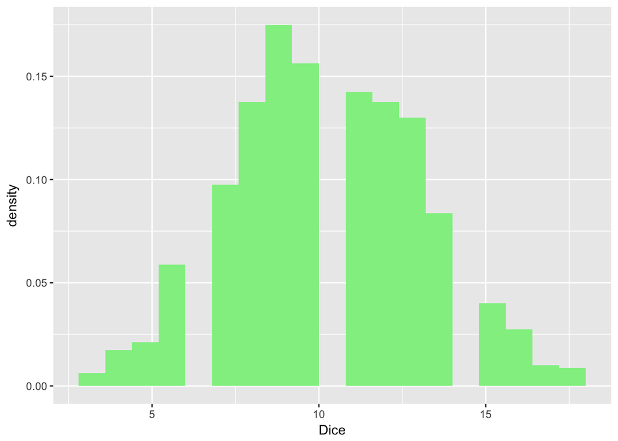

```r
set.seed(02138)
dice <- seq(1:6)
x <- c()
for (i in 1:1000){
  x[i]<-sum(sample(dice, 1), sample(dice, 1), sample(dice, 1))
}
# graphic
df<-data.frame(Dice=x)
library(ggplot2)
g <- ggplot(aes(Dice), data=df) +
  geom_histogram(binwidth = 0.8, fill='lightgreen', aes(y=..density..), position="identity")
g
```

可以看出點數的總和近似常態分佈，集中在10點附近。  
這個迴圈運用到「索引」的概念，紀錄每一次抽樣並且加總的結果，但是不需要顯示在螢幕上，而是成為一個向量，作為後續統計的資料。